# Lead Data Analysis

Wafaa Stohy 2025-06-26

#Introduction In this report, I perform a comprehensive statistical analysis on the lead concentration dataset. The analysis includes descriptive statistics, normality testing, homoscedasticity assessment, correlation analysis, and hypothesis testing.

# Load the dataset from the saved RData file

```r
load("D:/R programming/OMNIGENICS/project/lead.RData")
```

# View summary statistics of the dataset

```r
summary(lead)
```

```
##        Id             Area            Age              Sex
##  Min.   :101.0   Min.   :1.000   Min.   : 3.750   Min.   :1.000
##  1st Qu.:126.2   1st Qu.:1.000   1st Qu.: 6.375   1st Qu.:1.000
##  Median :151.5   Median :1.000   Median : 8.667   Median :1.000
##  Mean   :205.3   Mean   :1.637   Mean   : 9.054   Mean   :1.382
##  3rd Qu.:213.8   3rd Qu.:2.000   3rd Qu.:12.062   3rd Qu.:2.000
##  Max.   :505.0   Max.   :3.000   Max.   :15.917   Max.   :2.000
##
##       Iqf           Lead_type          Ld72            Ld73
##  Min.   : 50.00   Min.   :1.000   Min.   : 1.00   Min.   :15.00
##  1st Qu.: 82.25   1st Qu.:1.000   1st Qu.:24.00   1st Qu.:24.00
##  Median : 91.50   Median :1.000   Median :31.00   Median :28.00
##  Mean   : 91.91   Mean   :1.235   Mean   :34.17   Mean   :31.58
##  3rd Qu.:100.75   3rd Qu.:1.000   3rd Qu.:38.00   3rd Qu.:38.00
##  Max.   :141.00   Max.   :2.000   Max.   :99.00   Max.   :58.00
##
##      Totyrs           MAXFWT         Exposed
##  Min.   : 1.000   Min.   :13.00   Min.   :0.0000
##  1st Qu.: 4.000   1st Qu.:47.00   1st Qu.:0.0000
##  Median : 6.000   Median :52.00   Median :0.0000
##  Mean   : 6.725   Mean   :52.05   Mean   :0.2353
##  3rd Qu.: 9.000   3rd Qu.:59.00   3rd Qu.:0.0000
##  Max.   :15.000   Max.   :84.00   Max.   :1.0000
##                   NA's   :19
```

# Show the structure of the dataset

```r
str(lead)
```

```
## 'data.frame':    102 obs. of  11 variables:
##  $ Id       : int  101 102 103 104 105 106 107 108 109 110 ...
##  $ Area     : int  3 3 3 2 1 2 3 1 2 2 ...
##  $ Age      : num  11.08 9.42 11.08 6.92 11.25 ...
##  $ Sex      : int  1 1 1 1 1 1 1 2 2 1 ...
##  $ Iqf      : int  70 85 86 76 84 96 94 56 115 97 ...
##  $ Lead_type: int  1 1 1 1 1 1 1 1 1 1 ...
##  $ Ld72     : int  25 31 30 29 2 29 25 24 24 31 ...
##  $ Ld73     : int  18 28 29 30 34 25 24 15 16 24 ...
##  $ Totyrs   : int  11 6 5 5 11 6 6 15 7 7 ...
##  $ MAXFWT   : int  72 61 49 48 51 49 50 58 50 51 ...
##  $ Exposed  : num  0 0 0 0 0 0 0 0 0 0 ...
```

# Data Cleaning and Variable Labeling

# Convert categorical codes into readable factor labels

```r
lead$Area <- factor(lead$Area, labels = c("El Paso", "Texas", "USA"))
lead$Sex <- factor(lead$Sex, levels = c(1, 2), labels = c("Male", "Female"))
lead$Exposed <- factor(lead$Exposed, levels = c(0, 1), labels = c("Not_Exposed", "Exposed"))
```

# Convert MAXFWT to integer (if needed)

```r
lead$MAXFWT <- as.integer(lead$MAXFWT)
```

# Check the structure and summary again after cleaning

```r
str(lead)
```

```
## 'data.frame':    102 obs. of  11 variables:
##  $ Id       : int  101 102 103 104 105 106 107 108 109 110 ...
##  $ Area     : Factor w/ 3 levels "El Paso","Texas",..: 3 3 3 2 1 2 3 1 2 2 ...
##  $ Age      : num  11.08 9.42 11.08 6.92 11.25 ...
##  $ Sex      : Factor w/ 2 levels "Male","Female": 1 1 1 1 1 1 1 2 2 1 ...
##  $ Iqf      : int  70 85 86 76 84 96 94 56 115 97 ...
##  $ Lead_type: int  1 1 1 1 1 1 1 1 1 1 ...
##  $ Ld72     : int  25 31 30 29 2 29 25 24 24 31 ...
##  $ Ld73     : int  18 28 29 30 34 25 24 15 16 24 ...
##  $ Totyrs   : int  11 6 5 5 11 6 6 15 7 7 ...
##  $ MAXFWT   : int  72 61 49 48 51 49 50 58 50 51 ...
##  $ Exposed  : Factor w/ 2 levels "Not_Exposed",..: 1 1 1 1 1 1 1 1 1 1 ...
```

```r
summary(lead)
```

```
##        Id             Area         Age             Sex
##  Min.   :101.0   El Paso:52   Min.   : 3.750   Male  :63
##  1st Qu.:126.2   Texas  :35   1st Qu.: 6.375   Female:39
##  Median :151.5   USA    :15   Median : 8.667
##  Mean   :205.3                Mean   : 9.054
##  3rd Qu.:213.8                3rd Qu.:12.062
##  Max.   :505.0                Max.   :15.917
##
##       Iqf           Lead_type          Ld72            Ld73
##  Min.   : 50.00   Min.   :1.000   Min.   : 1.00   Min.   :15.00
##  1st Qu.: 82.25   1st Qu.:1.000   1st Qu.:24.00   1st Qu.:24.00
##  Median : 91.50   Median :1.000   Median :31.00   Median :28.00
##  Mean   : 91.91   Mean   :1.235   Mean   :34.17   Mean   :31.58
##  3rd Qu.:100.75   3rd Qu.:1.000   3rd Qu.:38.00   3rd Qu.:38.00
##  Max.   :141.00   Max.   :2.000   Max.   :99.00   Max.   :58.00
##
##      Totyrs           MAXFWT             Exposed
##  Min.   : 1.000   Min.   :13.00   Not_Exposed:78
##  1st Qu.: 4.000   1st Qu.:47.00   Exposed    :24
##  Median : 6.000   Median :52.00
##  Mean   : 6.725   Mean   :52.05
##  3rd Qu.: 9.000   3rd Qu.:59.00
##  Max.   :15.000   Max.   :84.00
##                   NA's   :19
```

## Descriptive Statistics

This section summarizes the data using descriptive statistics for both categorical and numeric variables.

### Categorical Variables

We use a frequency table to explore how observations are distributed across **Area**, **Sex**, and **Exposure status**.

```r
table(lead$Area, lead$Sex, lead$Exposed)
```

```
## , ,  = Not_Exposed
##
##
##           Male Female
##   El Paso   19     16
##   Texas     14     15
##   USA       13      1
##
## , ,  = Exposed
##
##
##           Male Female
##   El Paso   12      5
##   Texas      4      2
##   USA        1      0
```

### Numeric Variables

Now, we calculate basic descriptive statistics for all numeric variables:

- Mean
- Median
- Minimum
- Maximum
- First Quartile (Q1)
- Third Quartile (Q3)

#### Extract numeric columns

```r
numeric_cols <- sapply(lead, is.numeric)
numeric_data <- lead[, numeric_cols]
```

#### Mean of numeric variables

```r
means <- colMeans(numeric_data, na.rm = TRUE )
means
```

```
##         Id        Age        Iqf  Lead_type       Ld72       Ld73
## 205.303922   9.053922  91.911765   1.235294  34.166667  31.578431
##     Totyrs     MAXFWT
##   6.725490  52.048193
```

#### Median of numeric variables

```r
medians <- apply(numeric_data, 2, median, na.rm = TRUE)
medians
```

```
##         Id        Age        Iqf  Lead_type       Ld72       Ld73
## 151.500000   8.666667  91.500000   1.000000  31.000000  28.000000
##     Totyrs     MAXFWT
##   6.000000  52.000000
```

#### Minimum values

```r
mins <- apply(numeric_data, 2, min, na.rm = TRUE)
mins
```

```
##        Id       Age       Iqf Lead_type      Ld72      Ld73
##    101.00      3.75     50.00      1.00      1.00     15.00
##    Totyrs    MAXFWT
##      1.00     13.00
```

#### Maximum values

```r
maxs <- apply(numeric_data, 2, max, na.rm = TRUE)
maxs
```

```
##        Id       Age       Iqf Lead_type      Ld72      Ld73
## 505.00000  15.91667 141.00000   2.00000  99.00000  58.00000
##    Totyrs    MAXFWT
##  15.00000  84.00000
```

#### First Quartile (Q1)

```r
Q1 <- apply(numeric_data, 2, quantile, probs = 0.25, na.rm = TRUE )
Q1
```

```
##        Id       Age       Iqf Lead_type      Ld72      Ld73
##   126.250     6.375    82.250     1.000    24.000    24.000
##    Totyrs    MAXFWT
##     4.000    47.000
```

#### Third Quartile (Q3)

```r
Q3 <- apply(numeric_data, 2, quantile, probs = 0.75, na.rm = TRUE )
Q3
```

```
##        Id       Age       Iqf Lead_type      Ld72      Ld73
##  213.7500   12.0625  100.7500    1.0000   38.0000   38.0000
##    Totyrs    MAXFWT
##    9.0000   59.0000
```

### Interpretation

From these results: - The **mean and median** help us understand the central tendency of each variable. - The **minimum and maximum** values give us an idea of the range. - The **first and third quartiles (Q1, Q3)** help identify data spread and potential outliers.

These values are useful in detecting skewness, variability, and data quality issues.

# Bar chart showing gender distribution

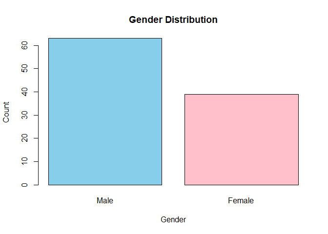

```r
barplot(table(lead$Sex), main = "Gender Distribution",
        xlab = "Gender", ylab = "Count", col = c("skyblue", "pink"))
```

This bar plot shows the distribution of gender in the dataset. There are more males than females. The height of each bar represents the number of people in each group.

# Bar chart showing mean MAXFWT for each gender

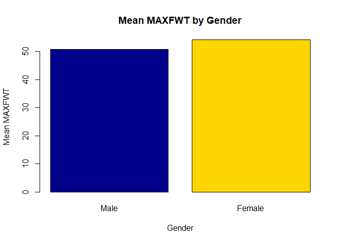

```r
barplot(tapply(lead$MAXFWT, lead$Sex, mean, na.rm= TRUE),
        main = "Mean MAXFWT by Gender", xlab = "Gender",
        ylab = "Mean MAXFWT", col = c("darkblue", "gold") )
```

-The bar plot shows that females have a higher average MAXFWT than males. -This suggests better finger-wrist tapping performance among females. -It may reflect gender differences in motor skills or lead exposure effects.

# Histogram showing the distribution of Age

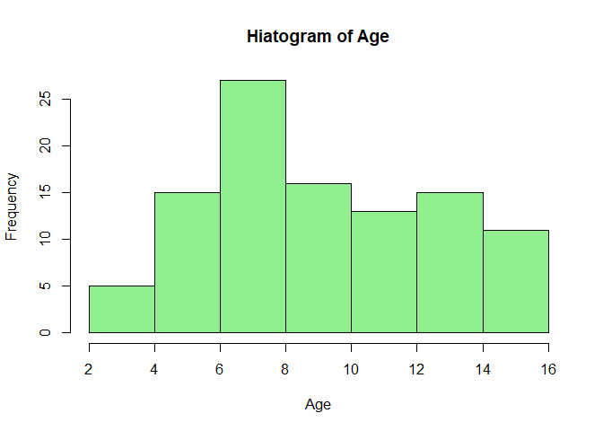

```r
hist(lead$Age, main = "Hiatogram of Age", xlab = "Age",
     ylab = "Frequency", col = "lightgreen", border = "black")
```

*No clear outliers are seen in the chart; the tail extends gradually toward older ages.

# Histogram showing the distribution of MAXFWT

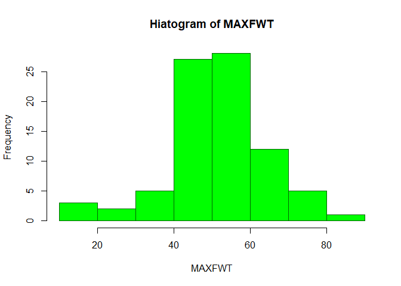

```r
hist(lead$MAXFWT, main = "Hiatogram of MAXFWT", xlab = "MAXFWT",
     ylab = "Frequency", col = "green", border = "darkgreen")
```

# Scatterplot of Ld72 vs MAXFWT colored by gender

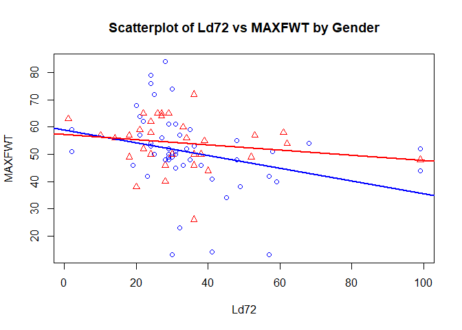

```r
plot(lead$Ld72, lead$MAXFWT, main = "Scatterplot of Ld72 vs MAXFWT by Gender",
     xlab = "Ld72", ylab = "MAXFWT",
     col = ifelse(lead$Sex== "Male","blue", "red"),
     pch = ifelse(lead$Sex== "Male", 1, 2))
abline(lm(MAXFWT ~ Ld72 , data = lead, subset = Sex== "Male"),
       col= "blue", lwd= 2)
abline(lm(MAXFWT ~ Ld72 , data = lead, subset = Sex== "Female"),
       col= "red", lwd= 2)
```

# Interpretation This scatterplot shows the relationship between lead levels in 1972 (Ld72) and finger-wrist tapping performance (MAXFWT), with data separated by gender:

1- Blue circles and line represent males. 2- Red triangles and line represent females.

-For males, the blue trend line goes downward. This suggests a negative relationship: as lead levels increase, their tapping performance tends to decrease.

-For females, the red trend line is nearly flat, which means no strong relationship between lead exposure and tapping performance.

-Boys may be more affected by lead exposure, showing reduced motor function with higher lead levels.

-Girls appear to be less affected, or the effect is not as strong or visible.

*This may suggest that lead exposure negatively affects motor skills in males more than in females.

# Boxplot of Age grouped by Ld72

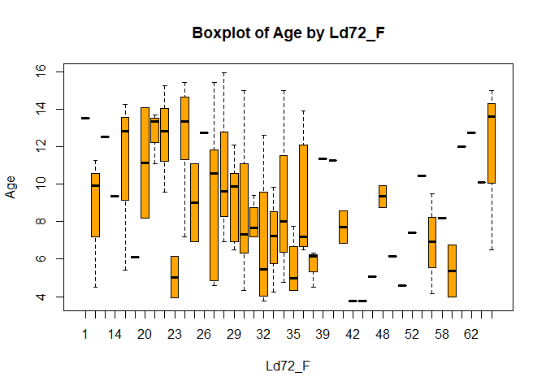

```r
boxplot(Age ~ factor(lead$Ld72), data = lead, main= 'Boxplot of Age by Ld72_F',
        xlab = "Ld72_F", ylab = "Age", col= "orange")
```

#Interpretation This boxplot shows how Age is distributed across different levels of Ld72_F (lead levels in 1972 grouped or categorized):

-Each vertical box represents the age range for children at a certain lead level group.

-The boxes show the spread of ages: from youngest to oldest.

-In many groups, younger children (ages 5–10) are more common.

-Some boxes are tall (more variation in ages), while others are short (less variation).

-Outliers appear as small horizontal lines outside the boxes in some groups.

##Observation: There is no clear increasing or decreasing pattern between lead exposure level and age. However, lead exposure is present across all ages, including very young children, indicating early environmental exposure.

# Boxplot of Age grouped by Ld73

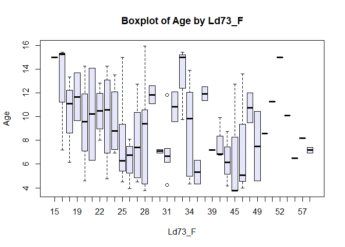

```r
boxplot(Age ~ factor(lead$Ld73), data = lead, main= 'Boxplot of Age by Ld73_F',
        xlab = "Ld73_F", ylab = "Age", col= "lavender")
```

#Interpretation This boxplot shows how Age is distributed across different levels of Ld73_F (lead levels in 1973):

##Observation: There is no clear pattern between lead level and age. Children of many different ages are found at each level of lead exposure. This suggests that in 1973, lead exposure was affecting children across a wide age range, including both younger and older children.

#Outlier Detection # Explore the data for any existing outliers, identify them (do NOT remove them if found).

```r
for (var_name in names(numeric_data)) {
  outliers <- boxplot(numeric_data[[var_name]], plot = FALSE)$out
  if (length(outliers) > 0) {
    cat("\nVariable:", var_name, "\n")
    cat("Number of outliers:", length(outliers), "\n")
    print(lead[lead[[var_name]] %in% outliers, ])
  }
}
```

```
##
## Variable: Id
## Number of outliers: 20
##      Id    Area      Age    Sex Iqf Lead_type Ld72 Ld73 Totyrs
## 98  401     USA 4.333333   Male 107         1   35   34      3
## 99  402   Texas 4.833333 Female 104         1   27   27      4
## 100 403 El Paso 3.916667   Male  85         1   23   26      3
## 101 404 El Paso 4.583333   Male  76         1   27   20      4
## 102 405 El Paso 4.500000   Male  95         1    2   27      4
## 103 406   Texas 3.750000   Male  86         1   32   28      4
## 104 407     USA 4.250000   Male  89         1   33   31      4
## 105 408     USA 4.333333   Male  76         1   32   28      4
## 106 409   Texas 4.333333 Female  96         1   35   37      4
## 107 410   Texas 5.583333   Male 101         1   35   34      3
## 108 411   Texas 4.333333 Female 108         1   30   34      4
```

[output cut: 136 more lines]

#What do you think? Several outliers were detected in the dataset:

Id has 20 outliers, which likely represent a distinct group of participants added later in the study.

Iqf has 2 outliers (very high and low IQ values), which might influence statistical analysis.

Lead_type shows 24 outliers, indicating a clear separation between exposure levels.

Ld72 (lead level in 1972) has 10 outliers, including very high values likely due to environmental exposure.

MAXFWT has 7 outliers, including extremely high or low tapping scores that may affect correlation analysis.

These outliers are not removed but should be noted, as they can impact results and assumptions of normality or homogeneity in further tests.

# Testing for normality / homoscedasticity (for all features mentioned above)

# Define variables to test

```r
testing_vars <- c("Age", "Iqf", "Ld72", "Ld73", "Totyrs", "MAXFWT")
```

#Normality Tests

```r
cat("Normality Tests:\n")
```

```
## Normality Tests:
```

```
##
## Variable: Age
```

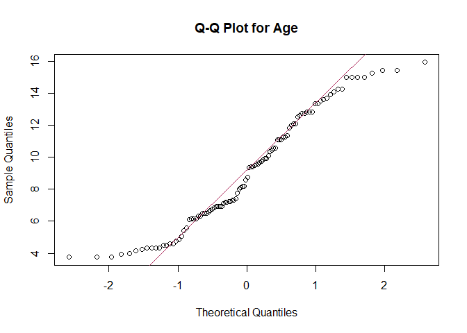

```
## Shapiro-Wilk p-value: 0.0004676722
```

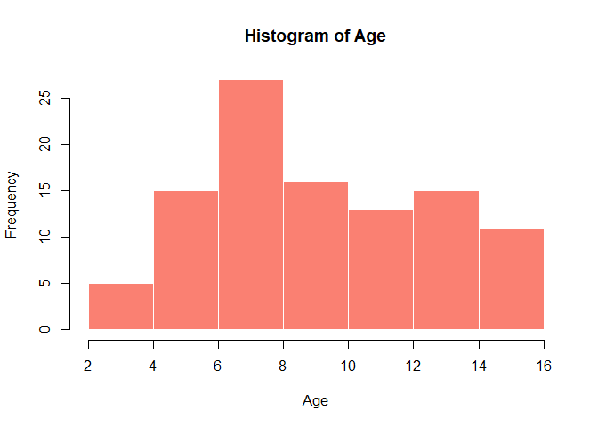

```
##
## Variable: Iqf
```

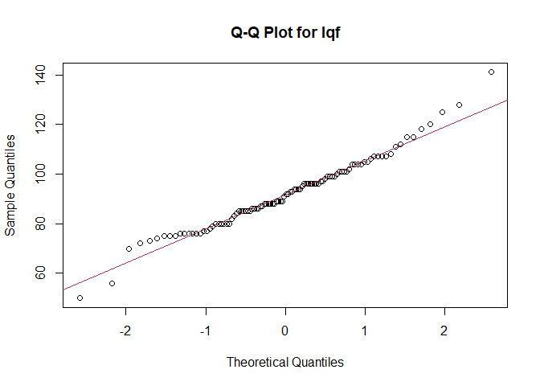

```
## Shapiro-Wilk p-value: 0.07333922
```

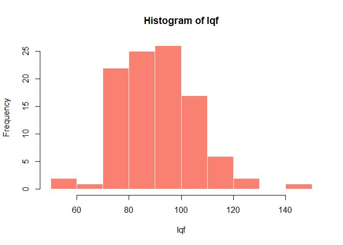

```
##
## Variable: Ld72
```

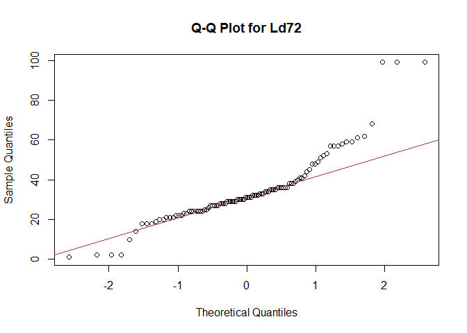

```
## Shapiro-Wilk p-value: 3.187765e-08
```

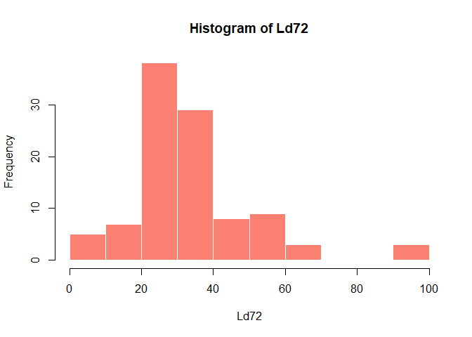

```
##
## Variable: Ld73
```

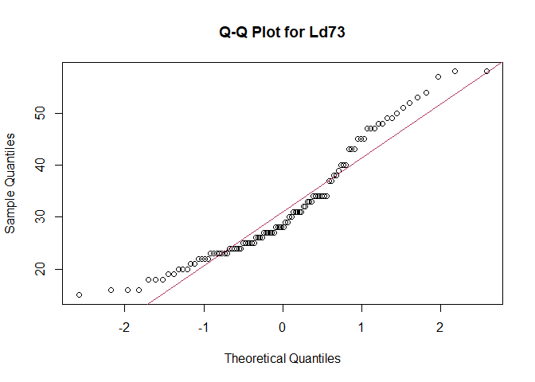

```
## Shapiro-Wilk p-value: 3.51539e-05
```

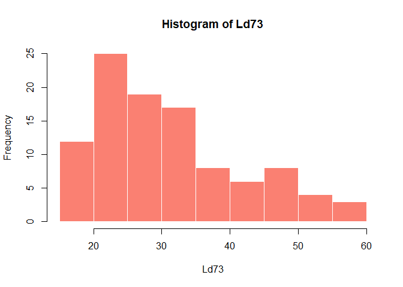

```
##
## Variable: Totyrs
```

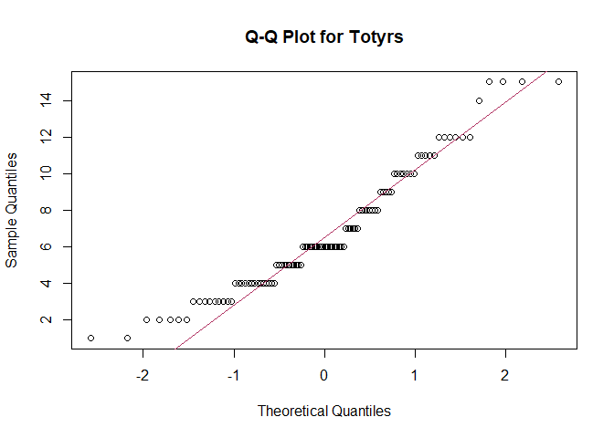

```
## Shapiro-Wilk p-value: 0.0002998423
```

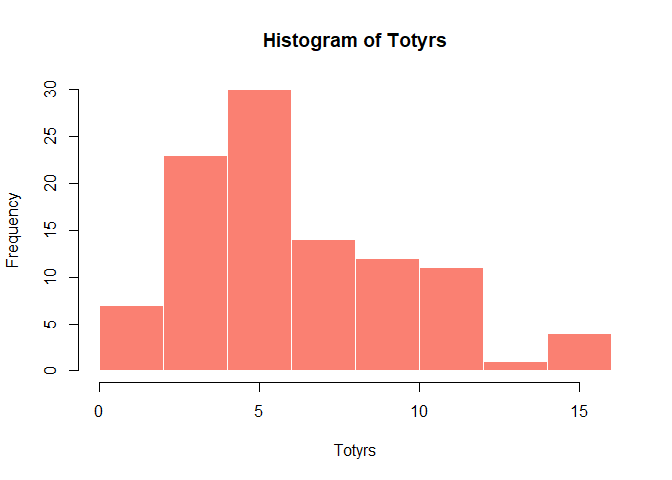

```
##
## Variable: MAXFWT
```

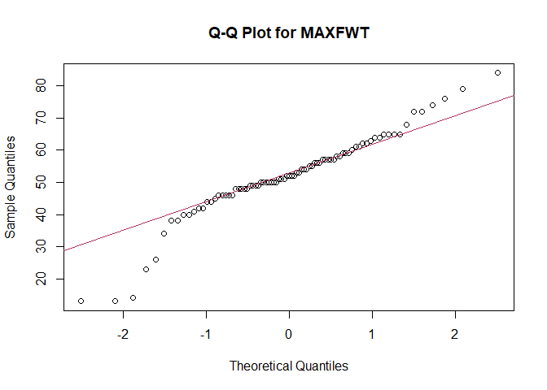

```
## Shapiro-Wilk p-value: 0.0005635958
```

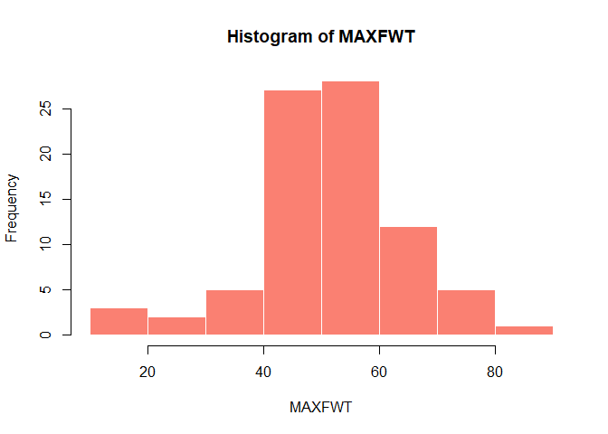

```r
for(var in testing_vars) {
  cat("\nVariable:", var, "\n")

  qqnorm(lead[[var]], main = paste("Q-Q Plot for", var))
  qqline(lead[[var]], col = "maroon")

  shapiro <- shapiro.test(lead[[var]])
  cat("Shapiro-Wilk p-value:", shapiro$p.value, "\n")

  hist(lead[[var]],
       main = paste("Histogram of", var),
       xlab = var,
       col = "salmon",
       border = "white")
}
```

#Homoscedasticity Tests

```r
cat("\n\nHomoscedasticity Tests (between genders):\n")
```

```
##
##
## Homoscedasticity Tests (between genders):
```

```r
# Ensure 'Sex' is treated as a factor
is.factor(lead$Sex)
```

```
## [1] TRUE
```

```r
# Install and load the 'car' package if not already installed
install.packages("car")
library(car)
for(var in testing_vars) {
  cat("\nVariable:", var, "\n")

  # Levene's Test

  levene <- leveneTest(lead[[var]] ~ lead$Sex)
  print(levene)

  # Bartlett's Test

  bartlett <- bartlett.test(lead[[var]] ~ lead$Sex)
  print(bartlett)
}
```

```
##
## Variable: Age
## Levene's Test for Homogeneity of Variance (center = median)
##        Df F value Pr(>F)
## group   1  0.7486  0.389
##       100
##
##  Bartlett test of homogeneity of variances
##
## data:  lead[[var]] by lead$Sex
## Bartlett's K-squared = 0.20663, df = 1, p-value = 0.6494
##
##
## Variable: Iqf
## Levene's Test for Homogeneity of Variance (center = median)
##        Df F value Pr(>F)
## group   1  0.1106 0.7401
##       100
##
##  Bartlett test of homogeneity of variances
##
## data:  lead[[var]] by lead$Sex
## Bartlett's K-squared = 0.0076978, df = 1, p-value = 0.9301
##
##
## Variable: Ld72
## Levene's Test for Homogeneity of Variance (center = median)
##        Df F value Pr(>F)
## group   1  0.0339 0.8542
##       100
##
##  Bartlett test of homogeneity of variances
##
## data:  lead[[var]] by lead$Sex
## Bartlett's K-squared = 0.14997, df = 1, p-value = 0.6986
##
##
## Variable: Ld73
## Levene's Test for Homogeneity of Variance (center = median)
##        Df F value Pr(>F)
```

[output cut: 16 more lines]

```
##
## data:  lead[[var]] by lead$Sex
## Bartlett's K-squared = 0.98997, df = 1, p-value = 0.3197
##
##
## Variable: MAXFWT
## Levene's Test for Homogeneity of Variance (center = median)
##       Df F value Pr(>F)
## group  1  1.8476 0.1778
##       81
##
##  Bartlett test of homogeneity of variances
##
## data:  lead[[var]] by lead$Sex
## Bartlett's K-squared = 7.1485, df = 1, p-value = 0.007503
```

#What do you think

Based on the results of the normality and homoscedasticity tests:

Most variables (Age, Ld72, Ld73, Totyrs, MAXFWT) are not normally distributed (Shapiro-Wilk p-value < 0.05). Only Iqf appears normally distributed. -Therefore, non-parametric tests are more appropriate for further analysis.

The variance between genders is mostly equal for all variables (Levene’s and Bartlett’s p-values > 0.05), except for MAXFWT, which showed unequal variance in Bartlett’s test (p = 0.0075). This should be considered when comparing groups.

#Correlation Analysis Exploring the relationship (correlation) between different variables in the dataset, especially how MAXFWT (maximum finger-wrist tapping score) relates to Ld72 and Ld73 (blood lead levels in 1972 and 1973).

#Calculate Spearman Correlation Coefficients Most variables are not normally distributed (based on Shapiro-Wilk test) and there are outliers in the data.So,Spearman is better for non-normal data and outliers.

```r
cor(lead$MAXFWT, lead$Ld72, use = "complete.obs", method = "spearman")
```

```
## [1] -0.3984387
```

```r
cor(lead$MAXFWT, lead$Ld73, use = "complete.obs", method = "spearman")
```

```
## [1] -0.3182327
```

#Correlation Results Interpretation We calculated the Spearman correlation between:

MAXFWT and Ld72: -0.398 MAXFWT and Ld73: -0.318

These values show a moderate negative correlation. This means:

Higher blood lead levels (Ld72 or Ld73) are associated with lower MAXFWT scores, suggesting a possible negative impact of lead exposure on children’s motor performance.

The negative values do not indicate a strong relationship, but there is a noticeable trend.

#Create Correlation Matrix

```r
cormat = cor(lead[, c("Age", "Iqf", "Ld72", "Ld73","Totyrs","MAXFWT")],
             use = "complete.obs", method = "spearman")
```

#Visualize the Correlations

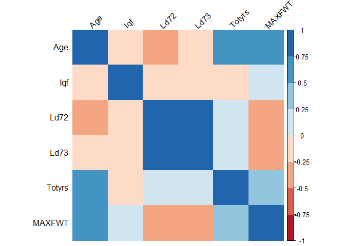

```r
install.packages("corrplot")
install.packages("RColorBrewer")
library(corrplot)
library(RColorBrewer)
corrplot(cormat, method = "color", col = brewer.pal(n = 8, name = "RdBu"),
         tl.col = "black", tl.srt = 45)
```

# Interpretation A positive correlation (closer to +1) means both variables increase together.

A negative correlation (closer to -1) means as one increases, the other decreases.

Values near 0 indicate no strong relationship.

###Long-term Effect

Lead level in 1972 is related to current age.

This means lead may stay in the body and affect people for a long time.

###Stable Lead Levels

Lead levels in 1972 and 1973 are almost the same.

This shows that exposure continued or lead stays in the body for a long time.

#Confidence Intervals for MAXFWT (per Gender) We estimate the average range in which the true mean of MAXFWT lies for each gender, using different confidence levels.

```r
# Subset MAXFWT values for males and females
males <- subset(lead, Sex == "Male")
females <- subset(lead, Sex == "Female")

# Male confidence intervals
cat("Confidence Intervals for Males (MAXFWT):\n")
```

```
## Confidence Intervals for Males (MAXFWT):
```

```r
cat("90% CI:", t.test(males$MAXFWT, conf.level = 0.90)$conf.int, "\n")
```

```
## 90% CI: 47.19258 54.16742
```

```r
cat("95% CI:", t.test(males$MAXFWT, conf.level = 0.95)$conf.int, "\n")
```

```
## 95% CI: 46.49985 54.86015
```

```r
cat("99% CI:", t.test(males$MAXFWT, conf.level = 0.99)$conf.int, "\n\n")
```

```
## 99% CI: 45.10538 56.25462
```

```r
# Female confidence intervals
cat("Confidence Intervals for Females (MAXFWT):\n")
```

```
## Confidence Intervals for Females (MAXFWT):
```

```r
cat("90% CI:", t.test(females$MAXFWT, conf.level = 0.90)$conf.int, "\n")
```

```
## 90% CI: 51.36321 56.87921
```

```r
cat("95% CI:", t.test(females$MAXFWT, conf.level = 0.95)$conf.int, "\n")
```

```
## 95% CI: 50.80466 57.43776
```

```r
cat("99% CI:", t.test(females$MAXFWT, conf.level = 0.99)$conf.int, "\n")
```

```
## 99% CI: 49.6624 58.58003
```

#How would you describe those inferences and what do you observe in terms of the interval width when request higher confidence (i.e. 99% C.I.)? A 90% confidence interval means: “We are 90% confident that the true mean lies within this range.”

A 95% confidence interval means: “We are 95% confident the true mean lies in this range.”

A 99% confidence interval means: “We are 99% confident the true mean is within this wider range.”

#What happens to interval width when confidence increases (e.g. 99% CI)? The higher the confidence level (like 99%), the wider the confidence interval. This is because we need a bigger range to be more sure that the true mean is inside it. A higher confidence level means less precision but more certainty.

## Hypothesis Testing for MAXFWT by Gender

### Hypotheses

- **H₀ (Null Hypothesis):** The mean of MAXFWT is equal for males and females.
- **H₁ (Alternative Hypothesis):** The mean of MAXFWT is different between males and females.

```r
# Subset data
male_data <- lead$MAXFWT[lead$Sex == "Male"]
female_data <- lead$MAXFWT[lead$Sex == "Female"]

# Two-sample t-test (equal variance assumed)
t.test(MAXFWT ~ Sex, data = lead, var.equal = TRUE)
```

```
##
##  Two Sample t-test
##
## data:  MAXFWT by Sex
## t = -1.1929, df = 81, p-value = 0.2364
## alternative hypothesis: true difference in means between group Male and group Female is not equal to 0
## 95 percent confidence interval:
##  -9.181028  2.298604
## sample estimates:
##   mean in group Male mean in group Female
##             50.68000             54.12121
```

#Interpretation -The p-value is greater than 0.05, so we do not reject the null hypothesis. -That means we do not have strong evidence that the means are different between males and females.

#Check Test Assumptions #1. Normality Test (Shapiro-Wilk)

```r
shapiro.test(male_data)
```

```
##
##  Shapiro-Wilk normality test
##
## data:  male_data
## W = 0.92914, p-value = 0.005127
```

```r
shapiro.test(female_data)
```

```
##
##  Shapiro-Wilk normality test
##
## data:  female_data
## W = 0.95821, p-value = 0.2299
```

#Interpretation -If p-value > 0.05 → The data is normal. -Male data: p-value < 0.05 → Not normal -Female data: p-value > 0.05 → Normal So, normality is not perfectly met, but the t-test is usually robust if sample size is not too small.

#2. Equal Variance Test (Levene’s Test)

```r
library(car)
leveneTest(MAXFWT ~ Sex, data = lead)
```

```
## Levene's Test for Homogeneity of Variance (center = median)
##       Df F value Pr(>F)
## group  1  1.8476 0.1778
##       81
```

#Interpretation -p-value = 0.1778 > 0.05 → We assume equal variances. So, the equal variance assumption is met.

## Hypothesis Test: Effect of Ld72 on MAXFWT

We hypothesize that MAXFWT is **lower** in the group with `Ld72 > 40` compared to the group with `Ld72 ≤ 40`.

### Welch Two Sample t-test

```r
t.test(group_high, group_low, alternative = "less", var.equal = FALSE)
```

[output not shown]

```
##
##  Welch Two Sample t-test
##
## data:  group_high and group_low
## t = -3.0115, df = 25.61, p-value = 0.00289
## alternative hypothesis: true difference in means is less than 0
## 95 percent confidence interval:
##       -Inf -4.453152
## sample estimates:
## mean of x mean of y
##  44.00000  54.27692
```

#Interpretation: The p-value is less than 0.05, so we reject the null hypothesis (H₀). -This means MAXFWT is significantly lower in the group with Ld72 > 40.

#Assumption Check: Equal Variance (Levene’s Test)

```r
install.packages("car")
```

[output not shown]

```r
library(car)
lead$Ld72_group <- ifelse(lead$Ld72 > 40, "High", "Low")
leveneTest(MAXFWT ~ Ld72_group, data = lead)
lead$Group <- paste(lead$Sex, ifelse(lead$Ld72 > 40, "HighLead", "LowLead"), sep = "_")
lead$Group
```

```
##   [1] "Male_LowLead"    "Male_LowLead"    "Male_LowLead"
##   [4] "Male_LowLead"    "Male_LowLead"    "Male_LowLead"
##   [7] "Male_LowLead"    "Female_LowLead"  "Female_LowLead"
##  [10] "Male_LowLead"    "Female_LowLead"  "Female_LowLead"
##  [13] "Male_LowLead"    "Male_LowLead"    "Male_LowLead"
##  [16] "Male_LowLead"    "Male_LowLead"    "Female_LowLead"
##  [19] "Male_LowLead"    "Male_LowLead"    "Male_LowLead"
##  [22] "Female_LowLead"  "Male_LowLead"    "Male_LowLead"
##  [25] "Male_LowLead"    "Female_LowLead"  "Female_LowLead"
##  [28] "Male_LowLead"    "Male_LowLead"    "Male_LowLead"
##  [31] "Female_LowLead"  "Female_LowLead"  "Male_LowLead"
##  [34] "Female_LowLead"  "Male_LowLead"    "Female_LowLead"
##  [37] "Female_LowLead"  "Female_LowLead"  "Male_LowLead"
##  [40] "Male_LowLead"    "Female_LowLead"  "Female_LowLead"
##  [43] "Female_LowLead"  "Male_LowLead"    "Male_LowLead"
```

[output cut: 19 more lines]

#MAXFWT Comparison between 4 Groups Based on Gender and Lead Level -We want to check if the finger-wrist tapping score (MAXFWT) is different between 4 groups:

1- Male with High Lead 2- Male with Low Lead 3- Female with High Lead 4- Female with Low Lead

#Step 1: Assumptions Check 1. Normality Test (Shapiro-Wilk)

```r
by(lead$MAXFWT, lead$Group, shapiro.test)
```

```
## lead$Group: Female_HighLead
##
##  Shapiro-Wilk normality test
##
## data:  dd[x, ]
## W = 0.88852, p-value = 0.3497
##
## ---------------------------------------------------
## lead$Group: Female_LowLead
##
##  Shapiro-Wilk normality test
##
## data:  dd[x, ]
## W = 0.95457, p-value = 0.2575
##
## ---------------------------------------------------
## lead$Group: Male_HighLead
##
##  Shapiro-Wilk normality test
##
## data:  dd[x, ]
## W = 0.85143, p-value = 0.02975
##
## ---------------------------------------------------
## lead$Group: Male_LowLead
##
##  Shapiro-Wilk normality test
##
## data:  dd[x, ]
## W = 0.9188, p-value = 0.01024
```

# 2. Equal Variance Test (Levene’s Test)

```r
leveneTest(MAXFWT ~ Group, data = lead)
```

[output not shown]

#Step 2: ANOVA Test -We used a one-way ANOVA to test if there are any differences in MAXFWT between the 4 groups.

```r
anova_result <- aov(MAXFWT ~ Group, data = lead)
summary(anova_result)
```

```
##             Df Sum Sq Mean Sq F value  Pr(>F)
## Group        3   2075   691.6   4.726 0.00438 **
## Residuals   79  11561   146.3
## ---
## Signif. codes:  0 '***' 0.001 '**' 0.01 '*' 0.05 '.' 0.1 ' ' 1
## 19 observations deleted due to missingness
```

Conclusion: There is a statistically significant difference in MAXFWT between at least two of the groups.

#Step 3: Post-hoc Test (Tukey HSD)

```r
TukeyHSD(anova_result)
```

```
##   Tukey multiple comparisons of means
##     95% family-wise confidence level
##
## Fit: aov(formula = MAXFWT ~ Group, data = lead)
##
## $Group
##                                        diff        lwr       upr
## Female_LowLead-Female_HighLead   1.08571429 -14.329012 16.500441
## Male_HighLead-Female_HighLead  -12.73846154 -29.446384  3.969461
## Male_LowLead-Female_HighLead     1.07027027 -14.057735 16.198275
## Male_HighLead-Female_LowLead   -13.82417582 -24.479928 -3.168424
## Male_LowLead-Female_LowLead     -0.01544402  -7.968237  7.937349
## Male_LowLead-Male_HighLead      13.80873181   3.572141 24.045323
##                                    p adj
## Female_LowLead-Female_HighLead 0.9977398
## Male_HighLead-Female_HighLead  0.1963570
## Male_LowLead-Female_HighLead   0.9977097
## Male_HighLead-Female_LowLead   0.0056405
## Male_LowLead-Female_LowLead    1.0000000
## Male_LowLead-Male_HighLead     0.0036906
```

All other comparisons > 0.05 Not statistically different

#Linear Regression Analysis ##Goal: We want to test if higher blood lead concentration in 1973 (Ld73) is related to lower motor performance (MAXFWT). We use a simple linear regression model.

###Fit the Linear Regression Model

```r
model <- lm(MAXFWT ~ Ld73, data = lead)
summary(model)
```

```
##
## Call:
## lm(formula = MAXFWT ~ Ld73, data = lead)
##
## Residuals:
##     Min      1Q  Median      3Q     Max
## -42.308  -5.808   0.993   7.584  30.661
##
## Coefficients:
##             Estimate Std. Error t value Pr(>|t|)
## (Intercept)  64.3660     4.0020  16.083   <2e-16 ***
## Ld73         -0.3938     0.1206  -3.266   0.0016 **
## ---
## Signif. codes:  0 '***' 0.001 '**' 0.01 '*' 0.05 '.' 0.1 ' ' 1
##
## Residual standard error: 12.2 on 81 degrees of freedom
##   (19 observations deleted due to missingness)
## Multiple R-squared:  0.1164, Adjusted R-squared:  0.1055
## F-statistic: 10.67 on 1 and 81 DF,  p-value: 0.0016
```

#Interpretation: Intercept (64.37): This is the expected MAXFWT when Ld73 = 0.

Slope for Ld73 (-0.3938): For every 1 unit increase in Ld73, MAXFWT decreases by about 0.39 units. This means higher lead level is associated with lower motor performance.

P-value (0.0016) < 0.05: The relationship is statistically significant, so we can say Ld73 has a meaningful effect on MAXFWT.

#Confidence Interval for the Slope

```r
confint(model)
```

```
##                  2.5 %     97.5 %
## (Intercept) 56.4032516 72.3287437
## Ld73        -0.6337485 -0.1539078
```

#Interpretation: We are 95% confident that the true slope lies between -0.63 and -0.15. Since the entire range is below zero, the negative relationship is confirmed.

# Prediction: MAXFWT when Ld73 = 100 μg/100 ml

```r
new_lead <- data.frame(Ld73 = 100)
predict(model, newdata = new_lead)
```

```
##        1
## 24.98319
```

#Interpretation: If a person’s lead level in 1973 was 100 μg/100 ml, the model predicts their MAXFWT score would be approximately 25, which is much lower than the average. This supports the idea that high lead levels are associated with poor motor function.

#Conclusion: The regression analysis shows a significant negative effect of lead concentration (Ld73) on motor ability (MAXFWT).

The slope is significantly negative, and the prediction at high lead levels confirms a sharp drop in performance.

These results support the hypothesis that lead exposure impairs motor function.